# act_report

## My Data Wrangling Project

```python
import pandas as pd
import numpy as np
import matplotlib.pyplot as plt
import seaborn as sns
from PIL import Image
from wordcloud import WordCloud, STOPWORDS
df = pd.read_csv('twitter_archive_master.csv')
```

Hello reader, Thank you for reading my article. In this article, I'll be talking about my second project for Udacity Data Analyst nano-degree.

For this project we were required to put our data wrangling abilities to the test. We were required to gather data from different sources, wrangle the data and analyse the data to produce insights. For those of us who do not know what data wrangling is, I will go ahead to give a brief definition of data wrangling.

> Data wrangling is the process of cleaning, organizing and transforming raw data into desired formats for analysis. The goal of data wrangling is to assure quality and useful data.

The data for this project was provided by Udacity. The datasets came in 3 different formats, a CSV, TSV and JSON. Two of the datasets contained information from a page 'WeRateDogs' on twitter. Information such as tweet Id, favorite count, etc. The other dataset contained dog breed predictions gotten by passing dog images through a deep learning AI.

After, I had gathered the datasets and assessed them, I was curious to know which dog breed was the most rated, which dog breeds got the most likes, whether the number of images uploaded influenced the number of likes and the year the page got the most engagements and the dog stage that got the most engagements. So I kept this questions in mind as I went through the data wrangling procedures.

After data cleaning and analysis, I was able to answer the questions I had in mind. The dog breeds that had the highest ratings was found to be Bouvier des Flandres and valley followed closely by Saluki, briard and Tibetan mastiff. The visualization below will further clarify this.

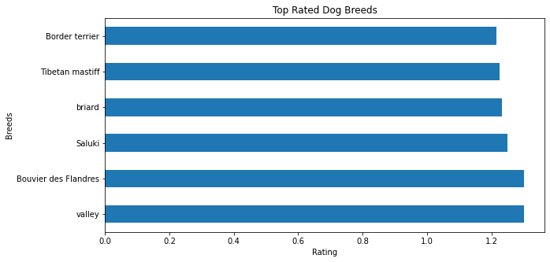

```python
breeds_df = df[df['breeds'] != 'NaN']
top_rated_breeds = breeds_df.groupby('breeds')['rating'].mean().sort_values(ascending = False).iloc[:6]
plt.subplots(figsize=(10, 5))
top_rated_breeds.plot(kind='barh')
plt.title('Top Rated Dog Breeds')
plt.xlabel('Rating')
plt.ylabel('Breeds');
```

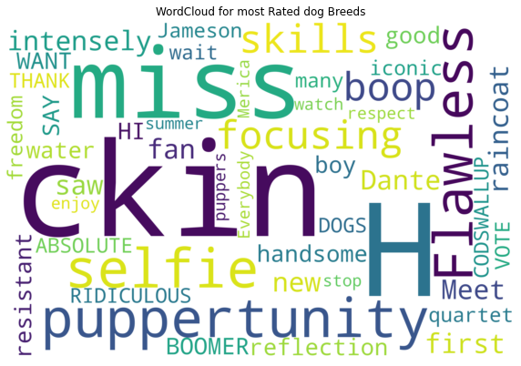

```python
most_rated = df.query('breeds == "Bouvier des Flandres" or breeds == "valley" or breeds == "Saluki"')
text = " ".join(dog for dog in most_rated.text)
stopwords = set(STOPWORDS)
stopwords.add("name")
stopwords.add("Gary")

word_cloud = WordCloud(
        width=3000,
        height=2000,
        random_state=1,
        background_color="white",
        stopwords=stopwords,
        ).generate(text)

#generate wordcloud
plt.subplots(figsize=(10, 15))
plt.imshow(word_cloud, interpolation="bilinear")
plt.axis("off")
plt.title('WordCloud for most Rated dog Breeds');
```

As seen above this dogs were described as flawless, good, hansome, etc, also, they were mostly in the pupper stage. Lets go ahead to checkout the most liked dog breeds.

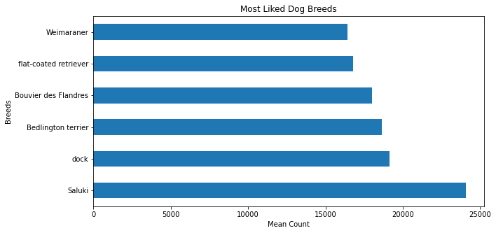

```python
top_breeds = breeds_df.groupby('breeds')['favorite_count'].mean().sort_values(ascending = False).iloc[:6]
plt.subplots(figsize=(10, 5))
top_breeds.plot(kind='barh')
plt.xlabel('Mean Count')
plt.ylabel('Breeds')
plt.title('Most Liked Dog Breeds');
```

The barchart above shows that Saluki is the most liked dog breed with about 5000 likes above dock, Bedlington terrier, Bouvier des Flandes, flat-coated retriever and Weimaraner. It is understandable how Saluki breed was the most liked breed because the breed is just angelic. Now, if you wondering what the dog looked like, you can see below

[figure not shown]

Lets go ahead to check how the page owner described this dog.

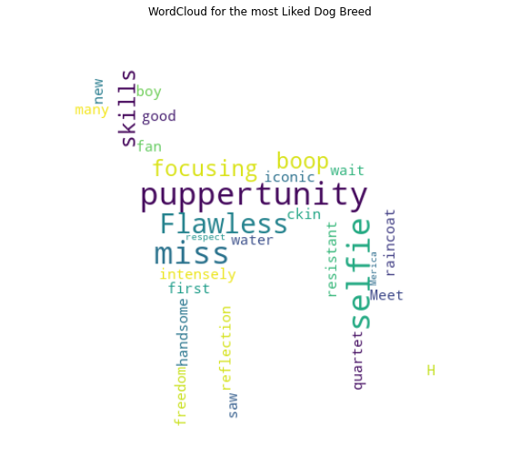

```python
most_fav = df.query('breeds == "Saluki"')
text = " ".join(dog for dog in most_fav.text)
mask = np.array(Image.open('saluki-removebg-preview.jpg'))
stopwords = set(STOPWORDS)
stopwords.add("name")
stopwords.add("Gary")
stopwords.add("Dante")
stopwords.add("Jameson")

word_cloud = WordCloud(
        width=mask.shape[1],
        height=mask.shape[0],
        background_color="white",
        random_state=1,
        mask = mask,
        stopwords=stopwords,
        ).generate(text)

plt.subplots(figsize=(10, 15))
plt.imshow(word_cloud, interpolation="bilinear")
plt.axis("off")
plt.title('WordCloud for the most Liked Dog Breed');
```

This breed was described as flawless, intensely handsome, iconic and so on. These dogs also were in the pupper stage. On the question of the year the twitter page had the most engagements, it was found that the page had the most engagements in 2017. Lets go ahead and visualize this

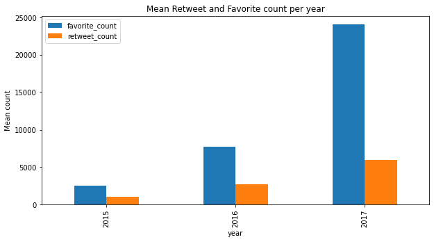

```python
df['date'] = pd.to_datetime(df['date'])
df['year'] = pd.DatetimeIndex(df['date']).year
date_plot = df.groupby('year')[['favorite_count', 'retweet_count']].mean()
fig, ax = plt.subplots(figsize=(10, 5))
date_plot.plot(kind = 'bar', ax=ax)
plt.title('Mean Retweet and Favorite count per year')
plt.ylabel('Mean count');
```

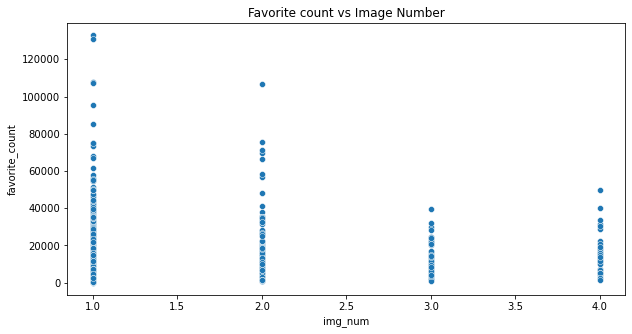

```python
fig, ax = plt.subplots(figsize=(10, 5))
sns.scatterplot(x='img_num', y='favorite_count', data=df)
plt.title('Favorite count vs Image Number');
```

And to the last but not the least, Which dog stage had the most engagements? It was found that the doggo, puppo stage had the most number of engagements. Lets go ahead and visualize this

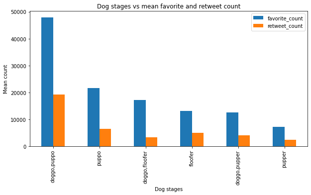

```python
stages = df.groupby('dog_stages')[['favorite_count', 'retweet_count']].mean()[1:].sort_values(by='favorite_count',ascending=False)
fig, ax = plt.subplots(figsize=(10, 5))
stages.plot(kind = 'bar', ax=ax)
plt.title('Dog stages vs mean favorite and retweet count')
plt.ylabel('Mean count')
plt.xlabel('Dog stages');
```

In conclusion, The following insights were drawn from the analysis:

Thank you so much for reading my article. Byebye :)